# Topología de la red eléctrica: grafo, vecindad eléctrica y exposición por cuadrante

# Parte 4 — Grafo eléctrico

## Construcción y control de calidad

**Nota metodológica importante:** el grafo se construye con `CODIGO_ESTRUCTURA_INICIO`/`CODIGO_ESTRUCTURA_FIN` como identificador de nodo físico, **no** con `NODO1_ID`/`NODO2_ID`. Se probaron ambas opciones: `NODO1_ID`/`NODO2_ID` producían un grafo extremadamente fragmentado (12,683 componentes, el mayor con solo 832 nodos — 0.5% del total), mientras que `CODIGO_ESTRUCTURA` da una tasa de coincidencia INICIO=FIN de 91.3% (vs. 70.1% del otro esquema) y un componente principal de 54,082 nodos (57.3% del total). Esto sugiere que `NODO1_ID`/`NODO2_ID` son identificadores de otro sistema (modelo de flujo de carga / SCADA) que no necesariamente se preservan entre tramos consecutivos de la digitalización física de la red.

```r
grafo_red <- secciones_linea_estructuras %>%
  filter(!is.na(CODIGO_ESTRUCTURA_INICIO), !is.na(CODIGO_ESTRUCTURA_FIN)) %>%
  select(CODIGO_ESTRUCTURA_INICIO, CODIGO_ESTRUCTURA_FIN, LONGITUD_M, NOMBRE_CIRCUITO) %>%
  igraph::graph_from_data_frame(directed = FALSE)

n_componentes <- igraph::components(grafo_red)$no
tamanos_componentes <- igraph::components(grafo_red)$csize

cat(sprintf(
  "Grafo construido: %d nodos, %d aristas, %d componentes conectados\n",
  igraph::vcount(grafo_red), igraph::ecount(grafo_red), n_componentes
))
```

```
## Grafo construido: 94401 nodos, 142030 aristas, 613 componentes conectados
```

```r
cat(sprintf(
  "Componente más grande: %d nodos (%.1f%% del total)\n",
  max(tamanos_componentes), 100 * max(tamanos_componentes) / sum(tamanos_componentes)
))
```

```
## Componente más grande: 54082 nodos (57.3% del total)
```

## Control de calidad: componentes vs. circuitos declarados

Con 613 componentes frente a ~174 circuitos declarados (~3.5 componentes por circuito en promedio), sigue habiendo cierta fragmentación — normal y manejable, probablemente por tramos con `CODIGO_ESTRUCTURA` mal digitalizado o extremos de red reales sin continuación registrada. No se busca un único componente global: cada `NOMBRE_CIRCUITO` es una red eléctricamente independiente de las demás, así que lo correcto es identificar el **componente principal dentro de cada circuito**, no un solo componente para toda la base.

```r
n_circuitos_distintos <- n_distinct(secciones_linea_estructuras$NOMBRE_CIRCUITO)

cat(sprintf(
  "Circuitos distintos declarados: %d | Componentes conectados en el grafo: %d (%.1f componentes/circuito)\n",
  n_circuitos_distintos, n_componentes, n_componentes / n_circuitos_distintos
))
```

```
## Circuitos distintos declarados: 174 | Componentes conectados en el grafo: 613 (3.5 componentes/circuito)
```

## Tamaño de los componentes

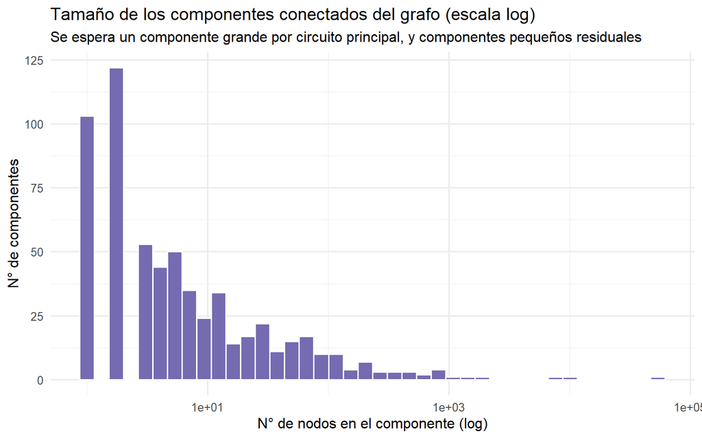

```r
data.frame(tamano = tamanos_componentes) %>%
  ggplot(aes(x = tamano)) +
  geom_histogram(bins = 40, fill = "#756bb1", color = "white") +
  scale_x_log10() +
  labs(
    title = "Tamaño de los componentes conectados del grafo (escala log)",
    subtitle = "Se espera un componente grande por circuito principal, y componentes pequeños residuales",
    x = "N° de nodos en el componente (log)", y = "N° de componentes"
  ) +
  theme_minimal(base_size = 12)
```

# Parte 5 — Vecindad eléctrica entre cuadrantes

## Nodo representativo de cada cuadrante

El nodo representativo se busca como el más cercano geográficamente al centroide real del cuadrante, usando `CODIGO_ESTRUCTURA_INICIO` (coherente con el identificador usado para construir el grafo) y sus coordenadas propias.

```r
estructura_coords <- secciones_linea_estructuras %>%
  select(CODIGO_ESTRUCTURA_INICIO, LON_INICIO, LAT_INICIO) %>%
  filter(!is.na(CODIGO_ESTRUCTURA_INICIO), !is.na(LON_INICIO), !is.na(LAT_INICIO)) %>%
  distinct(CODIGO_ESTRUCTURA_INICIO, .keep_all = TRUE) %>%
  st_as_sf(coords = c("LON_INICIO", "LAT_INICIO"), crs = 4326) %>%
  st_transform(3116)

cat(sprintf("Estructuras únicas con coordenadas: %d\n", nrow(estructura_coords)))
```

```
## Estructuras únicas con coordenadas: 86545
```

```r
centroides_sf <- centroides_cuadrante_real %>%
  rename(id_cuadrante = CUADRANTE) %>%
  mutate(id_cuadrante = as.character(id_cuadrante)) %>%
  st_as_sf(coords = c("lon", "lat"), crs = 4326, remove = FALSE) %>%
  st_transform(3116)

cuadrante_a_nodo <- st_join(centroides_sf, estructura_coords, join = st_nearest_feature)

cat(sprintf("Cuadrantes asignados a nodo representativo: %d\n", nrow(cuadrante_a_nodo)))
```

```
## Cuadrantes asignados a nodo representativo: 344
```

## Componente principal por circuito

Se identifica, para cada circuito, cuál de sus componentes conectados es el más grande — ese es el que se considera “la red real” de ese circuito; los demás fragmentos del mismo circuito se tratan como no válidos para el cálculo de distancia eléctrica.

```r
membresia_global <- igraph::components(grafo_red)$membership

estructura_circuito <- secciones_linea_estructuras %>%
  filter(!is.na(CODIGO_ESTRUCTURA_INICIO)) %>%
  distinct(CODIGO_ESTRUCTURA_INICIO, NOMBRE_CIRCUITO)

componente_por_circuito <- estructura_circuito %>%
  mutate(componente = membresia_global[CODIGO_ESTRUCTURA_INICIO]) %>%
  filter(!is.na(componente)) %>%
  count(NOMBRE_CIRCUITO, componente, name = "n_nodos") %>%
  group_by(NOMBRE_CIRCUITO) %>%
  slice_max(n_nodos, n = 1, with_ties = FALSE) %>%
  ungroup()

cat(sprintf("Circuitos con componente principal identificado: %d de %d\n",
            nrow(componente_por_circuito), n_circuitos_distintos))
```

```
## Circuitos con componente principal identificado: 173 de 174
```

```r
nodos_validos_por_circuito <- estructura_circuito %>%
  mutate(componente = membresia_global[CODIGO_ESTRUCTURA_INICIO]) %>%
  inner_join(componente_por_circuito, by = c("NOMBRE_CIRCUITO", "componente")) %>%
  pull(CODIGO_ESTRUCTURA_INICIO) %>%
  unique()

cat(sprintf("Nodos válidos (componente principal de su propio circuito): %d de %d totales en el grafo\n",
            length(nodos_validos_por_circuito), igraph::vcount(grafo_red)))
```

```
## Nodos válidos (componente principal de su propio circuito): 75028 de 94401 totales en el grafo
```

## Distancia eléctrica entre cuadrantes

Solo se calcula entre cuadrantes cuyo nodo representativo cae dentro del componente principal **de su propio circuito** (no un único componente global, ya que circuitos distintos son redes eléctricamente independientes entre sí).

```r
cuadrante_a_nodo_valido <- cuadrante_a_nodo %>%
  filter(CODIGO_ESTRUCTURA_INICIO %in% nodos_validos_por_circuito)

cat(sprintf("Cuadrantes con nodo válido para distancia eléctrica: %d de %d\n",
            nrow(cuadrante_a_nodo_valido), nrow(cuadrante_a_nodo)))
```

```
## Cuadrantes con nodo válido para distancia eléctrica: 252 de 344
```

```r
distancias_electricas <- igraph::distances(
  grafo_red,
  v = cuadrante_a_nodo_valido$CODIGO_ESTRUCTURA_INICIO,
  to = cuadrante_a_nodo_valido$CODIGO_ESTRUCTURA_INICIO,
  weights = igraph::E(grafo_red)$LONGITUD_M
)

rownames(distancias_electricas) <- cuadrante_a_nodo_valido$id_cuadrante
colnames(distancias_electricas) <- cuadrante_a_nodo_valido$id_cuadrante

cat(sprintf("Matriz de distancia eléctrica: %d x %d cuadrantes\n",
            nrow(distancias_electricas), ncol(distancias_electricas)))
```

```
## Matriz de distancia eléctrica: 252 x 252 cuadrantes
```

**Nota:** cuadrantes en circuitos distintos tendrán distancia `Inf` entre sí (no existe camino en el grafo) — esto es correcto eléctricamente, no un error. La matriz de vecindad (siguiente paso) solo conecta cuadrantes dentro del mismo circuito.

## Distribución de la distancia eléctrica al vecino más cercano

```r
diag(distancias_electricas) <- Inf   # excluir la distancia de un cuadrante a sí mismo
dist_min_electrica <- apply(distancias_electricas, 1, min)

cat(sprintf("Cuadrantes sin ningún otro cuadrante alcanzable en su circuito: %d de %d\n",
            sum(!is.finite(dist_min_electrica)), length(dist_min_electrica)))
```

```
## Cuadrantes sin ningún otro cuadrante alcanzable en su circuito: 3 de 252
```

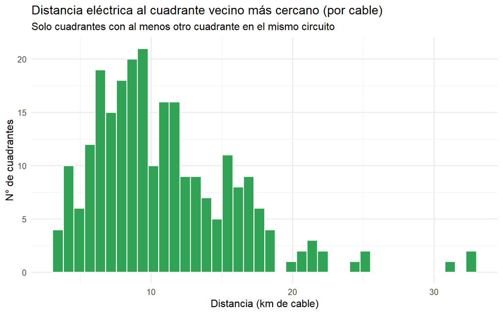

```r
data.frame(dist_min_m = dist_min_electrica) %>%
  filter(is.finite(dist_min_m)) %>%
  ggplot(aes(x = dist_min_m / 1000)) +
  geom_histogram(bins = 40, fill = "#31a354", color = "white") +
  labs(
    title = "Distancia eléctrica al cuadrante vecino más cercano (por cable)",
    subtitle = "Solo cuadrantes con al menos otro cuadrante en el mismo circuito",
    x = "Distancia (km de cable)", y = "N° de cuadrantes"
  ) +
  theme_minimal(base_size = 12)
```

## Construcción de la matriz de vecindad eléctrica

```r
UMBRAL_M <- as.numeric(quantile(dist_min_electrica[is.finite(dist_min_electrica)], 0.5, na.rm = TRUE))
# UMBRAL_M ≈ 9680 m

cat(sprintf("Nuevo umbral ajustado (mediana de distancia mínima): %.0f m\n", UMBRAL_M))
```

```
## Nuevo umbral ajustado (mediana de distancia mínima): 9680 m
```

```r
vecindad_electrica_bin <- (distancias_electricas <= UMBRAL_M) & is.finite(distancias_electricas)
diag(vecindad_electrica_bin) <- FALSE

n_vecinos_electricos <- rowSums(vecindad_electrica_bin)
cat(sprintf(
  "Umbral: %.0f m | Cuadrantes sin ningún vecino eléctrico dentro del umbral: %d de %d\n",
  UMBRAL_M, sum(n_vecinos_electricos == 0), length(n_vecinos_electricos)
))
```

```
## Umbral: 9680 m | Cuadrantes sin ningún vecino eléctrico dentro del umbral: 127 de 252
```

```r
pesos_electricos <- spdep::mat2listw(vecindad_electrica_bin * 1, style = "W", zero.policy = TRUE)
```

# Parte 6 — Comparación: vecindad geográfica vs. eléctrica

## Matriz de vecindad geográfica (referencia, ya usada en el modelo)

```r
if (sum(!st_is_valid(cuadrantes_infra)) > 0) {
  cuadrantes_infra <- st_make_valid(cuadrantes_infra)
}

vecinos_nb_geo <- spdep::poly2nb(cuadrantes_infra, queen = TRUE, row.names = cuadrantes_infra$id_cuadrante)
pesos_geograficos <- spdep::nb2listw(vecinos_nb_geo, style = "W", zero.policy = TRUE)
```

## ¿Cuánto se solapan ambas vecindades?

```r
ids_comunes <- intersect(cuadrante_a_nodo_valido$id_cuadrante, cuadrantes_infra$id_cuadrante)

# Para cada cuadrante común, ¿sus vecinos geográficos son también
# vecinos eléctricos?
comparacion_vecindad <- purrr::map_dfr(ids_comunes, function(id) {
  idx_geo <- which(cuadrantes_infra$id_cuadrante == id)
  vecinos_geo <- cuadrantes_infra$id_cuadrante[vecinos_nb_geo[[idx_geo]]]

  idx_elec <- which(rownames(vecindad_electrica_bin) == id)
  if (length(idx_elec) == 0) return(NULL)
  vecinos_elec <- colnames(vecindad_electrica_bin)[vecindad_electrica_bin[idx_elec, ]]

  data.frame(
    id_cuadrante   = id,
    n_vecinos_geo  = length(vecinos_geo),
    n_vecinos_elec = length(vecinos_elec),
    n_comunes      = length(intersect(vecinos_geo, vecinos_elec))
  )
})

resumen_comparacion <- comparacion_vecindad %>%
  summarise(
    prom_vecinos_geo  = mean(n_vecinos_geo),
    prom_vecinos_elec = mean(n_vecinos_elec),
    prom_comunes      = mean(n_comunes),
    pct_solape        = round(100 * mean(n_comunes / pmax(n_vecinos_geo, 1)), 1)
  )

kable(resumen_comparacion, digits = 2,
      caption = "Solape entre vecindad geográfica y vecindad eléctrica") %>%
  kable_styling(bootstrap_options = c("striped"), full_width = FALSE)
```

Solape entre vecindad geográfica y vecindad eléctrica

| prom_vecinos_geo | prom_vecinos_elec | prom_comunes | pct_solape |
| --- | --- | --- | --- |
| 6.82 | 0.6 | 0.6 | 10.4 |

```r
cat(sprintf(
  "\n%s\n",
  if (resumen_comparacion$pct_solape < 60) {
    "Solape bajo: confirma que la vecindad eléctrica captura relaciones distintas a la geográfica — vale la pena usarla en el modelo espacial, no es redundante."
  } else {
    "Solape alto: la vecindad eléctrica se parece bastante a la geográfica en este caso — su aporte marginal al modelo espacial puede ser menor."
  }
))
```

```
##
## Solape bajo: confirma que la vecindad eléctrica captura relaciones distintas a la geográfica — vale la pena usarla en el modelo espacial, no es redundante.
```